# Peer Assessment I - Statistics with R Capstone

First, let us load the data and necessary packages:

```r
load("ames_train.Rdata")
library(MASS)
library(dplyr)
library(ggplot2)
library(tidyr)
library(gridExtra)
```

#### Question 1

Make a labeled histogram (with 30 bins) of the ages of the houses in the data set, and describe the distribution.

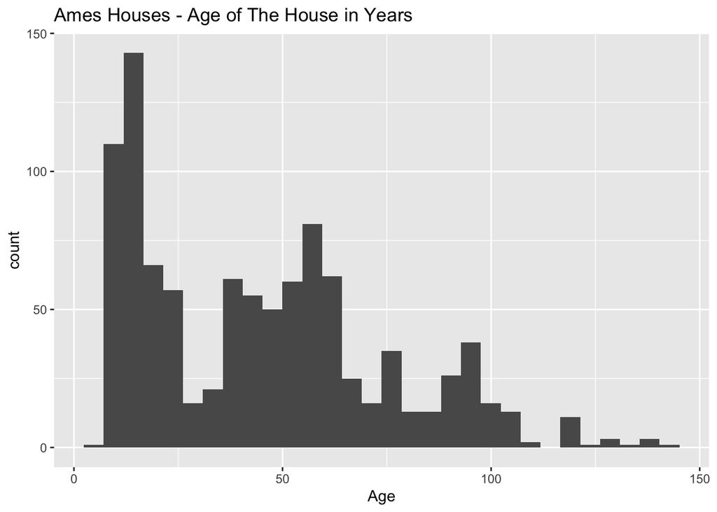

```r
houses_age <- ames_train %>%
  mutate(age = 2017 - Year.Built)

p <- ggplot(houses_age, aes(x=age)) + geom_histogram(bins=30)

p + labs(
  title = "Ames Houses - Age of The House in Years",
  x = "Age",
  y = "count",
)
```

#### Question 2

The mantra in real estate is “Location, Location, Location!” Make a graphical display that relates a home price to its neighborhood in Ames, Iowa. Which summary statistics are most appropriate to use for determining the most expensive, least expensive, and most heterogeneous (having the most variation in housing price) neighborhoods? Report which neighborhoods these are based on the summary statistics of your choice. Report the value of your chosen summary statistics for these neighborhoods.

```r
tapply(ames_train$price, ames_train$Neighborhood, summary)
```

```
## $Blmngtn
##    Min. 1st Qu.  Median    Mean 3rd Qu.    Max.
##  172500  182112  191000  198635  205000  246990
##
## $Blueste
##    Min. 1st Qu.  Median    Mean 3rd Qu.    Max.
##  116500  120200  123900  125800  130450  137000
##
## $BrDale
##    Min. 1st Qu.  Median    Mean 3rd Qu.    Max.
##   83000   88250   98750   98930  104975  125500
##
## $BrkSide
##    Min. 1st Qu.  Median    Mean 3rd Qu.    Max.
##   39300   93000  124000  122473  135000  207000
##
## $ClearCr
##    Min. 1st Qu.  Median    Mean 3rd Qu.    Max.
##  107500  164000  185000  193154  240000  277000
##
## $CollgCr
##    Min. 1st Qu.  Median    Mean 3rd Qu.    Max.
##  110000  160000  195800  196951  218836  475000
##
## $Crawfor
##    Min. 1st Qu.  Median    Mean 3rd Qu.    Max.
##   96500  154900  205000  204197  235000  392500
##
## $Edwards
##    Min. 1st Qu.  Median    Mean 3rd Qu.    Max.
##   61500  112250  127250  136322  148000  415000
##
## $Gilbert
##    Min. 1st Qu.  Median    Mean 3rd Qu.    Max.
##  133000  171500  183500  193328  199500  377500
##
## $Greens
##    Min. 1st Qu.  Median    Mean 3rd Qu.    Max.
##  155000  197375  212625  198562  213812  214000
##
```

[output cut: 55 more lines]

```
## $StoneBr
##    Min. 1st Qu.  Median    Mean 3rd Qu.    Max.
##  180000  241250  340692  339316  392608  591587
##
## $SWISU
##    Min. 1st Qu.  Median    Mean 3rd Qu.    Max.
##   80000  120000  134000  130620  149250  169000
##
## $Timber
##    Min. 1st Qu.  Median    Mean 3rd Qu.    Max.
##  175000  191250  232500  265192  342450  425000
##
## $Veenker
##    Min. 1st Qu.  Median    Mean 3rd Qu.    Max.
##  150000  188250  205750  233650  256375  385000
```

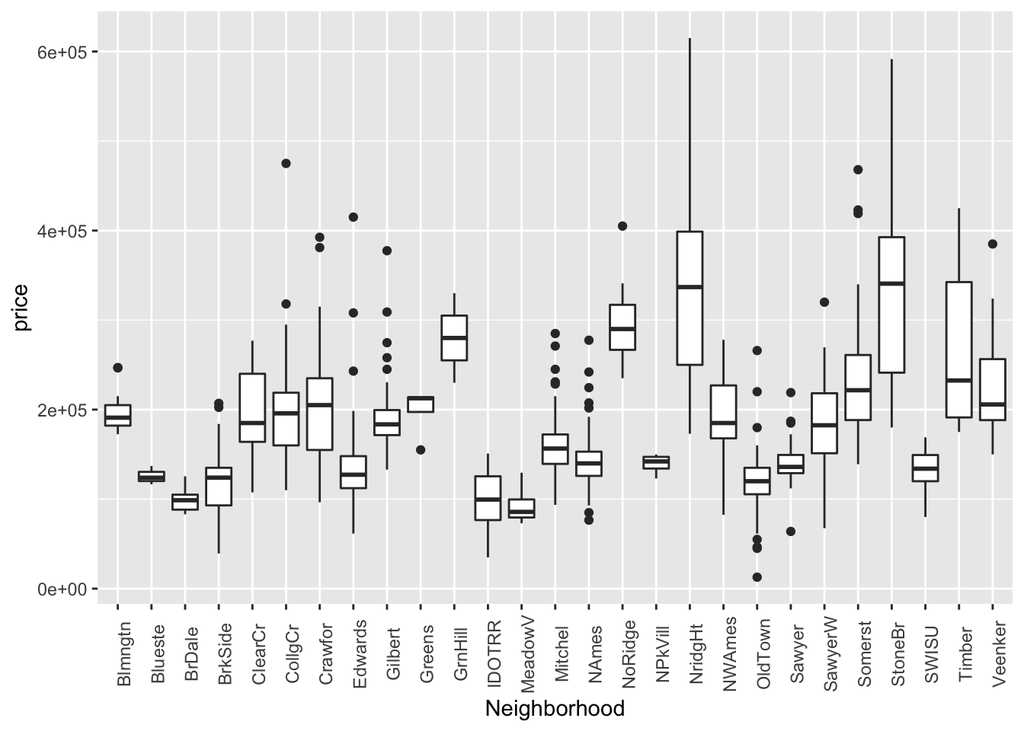

```r
fig <- ggplot(ames_train, aes(x=Neighborhood, y=price)) + geom_boxplot()
fig + theme(axis.text.x = element_text(angle=90))
```

The distribution of prices along neighborhoods can be easily spot checked using a boxplot. These kind of plots can easily determine median, max., min and outlier prices as well as the price distribution for each category.

From the plots and based on the summary statistics presented, we can determine the following neighborhoods as being:

1. MeadowV the least expensive with a median price of $85750
2. StoneBr the most expensive one with a median price of $340692
3. StoneBr, is the most heterogeneus, based in the IQR (InterQuartile Range) which is equal to $151358

#### Question 3

Which variable has the largest number of missing values? Explain why it makes sense that there are so many missing values for this variable.

```r
ames_train %>%
  summarise(across(everything(), ~ sum(is.na(.)))) %>%
  pivot_longer(cols = everything(), names_to = "Variable", values_to = "NAs") %>%
  arrange(desc(NAs)) %>%
  head(5)
```

```
## # A tibble: 5 × 2
##   Variable       NAs
##   <chr>        <int>
## 1 Pool.QC        997
## 2 Misc.Feature   971
## 3 Alley          933
## 4 Fence          798
## 5 Fireplace.Qu   491
```

The largest variable with missing information is the one related to the pool quality. There are 997 of 1000 houses from the dataset which don’t have a pool built in the house. That’s the reason why the amount of missing values is so large for this variable.

#### Question 4

We want to predict the natural log of the home prices. Candidate explanatory variables are lot size in square feet (Lot.Area), slope of property (Land.Slope), original construction date (Year.Built), remodel date (Year.Remod.Add), and the number of bedrooms above grade (Bedroom.AbvGr). Pick a model selection or model averaging method covered in the Specialization, and describe how this method works. Then, use this method to find the best multiple regression model for predicting the natural log of the home prices.

The analysis is started by exploring the variables and their correlation between each other. In this way we can have an intuiton of the colinearity among them. The objective is to find variables which are not correlated between them, but at the same time have a linear relationship with the target variable, which in this case is the log(price).

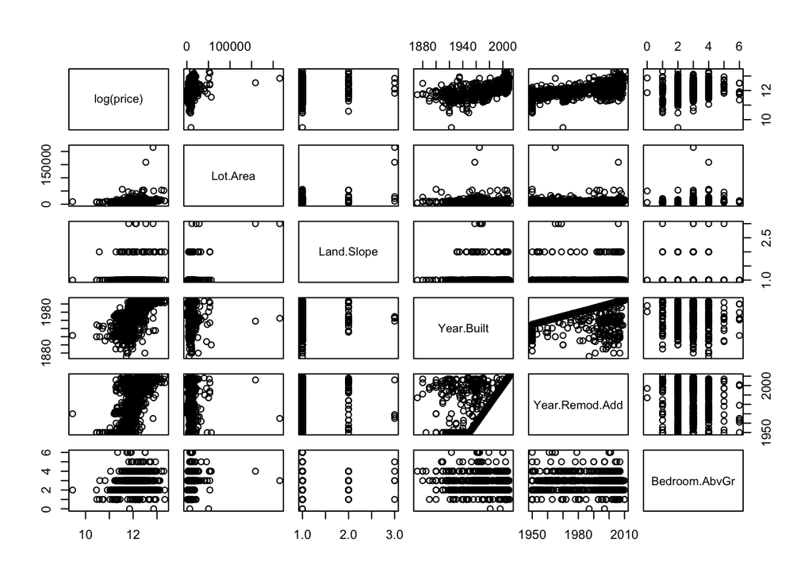

```r
pairs(log(price) ~ Lot.Area+Land.Slope+Year.Built+Year.Remod.Add+Bedroom.AbvGr,
      data=ames_train)
```

```r
lm_full <- lm(log(price) ~ Lot.Area+Land.Slope+Year.Built+Year.Remod.Add+
                Bedroom.AbvGr, data=ames_train)
summary(lm_full)
```

```
##
## Call:
## lm(formula = log(price) ~ Lot.Area + Land.Slope + Year.Built +
##     Year.Remod.Add + Bedroom.AbvGr, data = ames_train)
##
## Residuals:
##     Min      1Q  Median      3Q     Max
## -2.0878 -0.1651 -0.0211  0.1657  0.9945
##
## Coefficients:
##                  Estimate Std. Error t value Pr(>|t|)
## (Intercept)    -1.371e+01  8.574e-01 -15.996  < 2e-16 ***
## Lot.Area        1.028e-05  1.106e-06   9.296  < 2e-16 ***
## Land.SlopeMod   1.384e-01  4.991e-02   2.773  0.00565 **
## Land.SlopeSev  -4.567e-01  1.514e-01  -3.016  0.00263 **
## Year.Built      6.049e-03  3.788e-04  15.968  < 2e-16 ***
## Year.Remod.Add  6.778e-03  5.468e-04  12.395  < 2e-16 ***
## Bedroom.AbvGr   8.686e-02  1.077e-02   8.063 2.12e-15 ***
## ---
## Signif. codes:  0 '***' 0.001 '**' 0.01 '*' 0.05 '.' 0.1 ' ' 1
##
## Residual standard error: 0.279 on 993 degrees of freedom
## Multiple R-squared:  0.5625, Adjusted R-squared:  0.5598
## F-statistic: 212.8 on 6 and 993 DF,  p-value: < 2.2e-16
```

```r
final_model <- step(lm_full, direction = "backward", trace = FALSE)
summary(final_model)
```

```
##
## Call:
## lm(formula = log(price) ~ Lot.Area + Land.Slope + Year.Built +
##     Year.Remod.Add + Bedroom.AbvGr, data = ames_train)
##
## Residuals:
##     Min      1Q  Median      3Q     Max
## -2.0878 -0.1651 -0.0211  0.1657  0.9945
##
## Coefficients:
##                  Estimate Std. Error t value Pr(>|t|)
## (Intercept)    -1.371e+01  8.574e-01 -15.996  < 2e-16 ***
## Lot.Area        1.028e-05  1.106e-06   9.296  < 2e-16 ***
## Land.SlopeMod   1.384e-01  4.991e-02   2.773  0.00565 **
## Land.SlopeSev  -4.567e-01  1.514e-01  -3.016  0.00263 **
## Year.Built      6.049e-03  3.788e-04  15.968  < 2e-16 ***
## Year.Remod.Add  6.778e-03  5.468e-04  12.395  < 2e-16 ***
## Bedroom.AbvGr   8.686e-02  1.077e-02   8.063 2.12e-15 ***
## ---
## Signif. codes:  0 '***' 0.001 '**' 0.01 '*' 0.05 '.' 0.1 ' ' 1
##
## Residual standard error: 0.279 on 993 degrees of freedom
## Multiple R-squared:  0.5625, Adjusted R-squared:  0.5598
## F-statistic: 212.8 on 6 and 993 DF,  p-value: < 2.2e-16
```

As noticed from the summary report, the final model after the backward elimination method maintains the complete set of variables as this is the parsimonious model for the candidate’s list.

#### Question 5

Which home has the largest squared residual in the previous analysis (Question 4)? Looking at all the variables in the data set, can you explain why this home stands out from the rest (what factors contribute to the high squared residual and why are those factors relevant)?

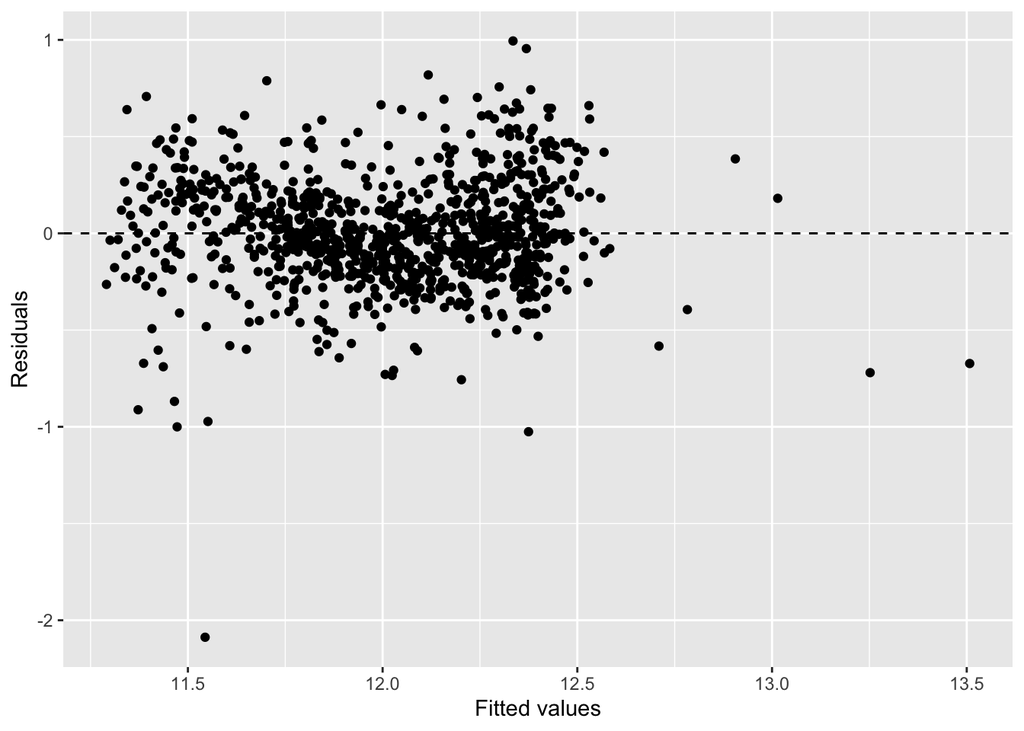

```r
ggplot(data = final_model, aes(x = .fitted, y = .resid)) +
  geom_point() +
  geom_hline(yintercept = 0, linetype = "dashed") +
  xlab("Fitted values") +
  ylab("Residuals")
```

Let’s now find out what is the largest residual. From the previous plot there’s only one with a squared value > 2.

```r
outlier <- which(final_model$residuals < -2)
print(outlier)
```

```
## 428
## 428
```

```r
# Let's get some standard values so we can compare
some_residuals <- which(final_model$residuals > -0.02 & final_model$residuals < 0)
some_residuals <- append(some_residuals, outlier)

ames_multiple_reg <- ames_train %>%
  select(c('price', 'Lot.Area', 'Land.Slope', 'Year.Built',
    'Year.Remod.Add', 'Bedroom.AbvGr')) %>%
  mutate(price = log(price))

print(some_residuals)
```

```
##  73  87 101 134 197 211 247 259 303 334 410 447 448 533 736 746 752 756 759 779
##  73  87 101 134 197 211 247 259 303 334 410 447 448 533 736 746 752 756 759 779
## 786 817 820 866 869 885 935 937 958 964 999 428
## 786 817 820 866 869 885 935 937 958 964 999 428
```

```r
ames_subset <- ames_multiple_reg[some_residuals,]
head(
  ames_subset[order(ames_subset$Year.Built),],
  10
)
```

```
## # A tibble: 10 × 6
##    price Lot.Area Land.Slope Year.Built Year.Remod.Add Bedroom.AbvGr
##    <dbl>    <int> <fct>           <int>          <int>         <int>
##  1  9.46     9656 Gtl              1923           1970             2
##  2 11.7     10998 Gtl              1941           1960             3
##  3 11.9      9480 Gtl              1942           1995             3
##  4 11.8      7200 Gtl              1950           1982             3
##  5 11.7      9280 Gtl              1951           1951             4
##  6 11.6      7801 Gtl              1951           1951             2
##  7 12.0     13300 Gtl              1956           2001             2
##  8 11.9      8712 Gtl              1957           2000             2
##  9 11.8      6970 Gtl              1961           1961             3
## 10 11.8     10205 Gtl              1962           1962             3
```

From the query, the observation 428 is determined as the one with the highest residual. The outlier’s house price is **considerably** lower than the rest of the houses from the dataset where the residual is closer to 0.

From the set of explanatory variables, the house building year appears to be the one which is impacting in the real price (vs. the modeled one). Even if the house has been remodeled later in time, particularly in 1970, this house forms part of the first wave of houses built in the city. Probably their basements and core structure are too old and that’s what has been evaluated when the price was determined. Looking at the variables in the full dataset, many of the indicators related to building quality qualifies the house in poor terms.

#### Question 6

Use the same model selection method you chose in Question 4 to again find the best multiple regression model to predict the natural log of home prices, but this time **replacing Lot.Area with log(Lot.Area)**. Do you arrive at a model including the same set of predictors?

```r
lm_log_lotArea <- lm(log(price) ~ log(Lot.Area)+Land.Slope+Year.Built+Year.Remod.Add+
                Bedroom.AbvGr, data=ames_train)

lm_log_lotArea <- step(lm_log_lotArea, direction = "backward", trace = FALSE)
summary(lm_log_lotArea)
```

```
##
## Call:
## lm(formula = log(price) ~ log(Lot.Area) + Land.Slope + Year.Built +
##     Year.Remod.Add + Bedroom.AbvGr, data = ames_train)
##
## Residuals:
##      Min       1Q   Median       3Q      Max
## -2.14050 -0.15650 -0.01561  0.15350  0.90854
##
## Coefficients:
##                  Estimate Std. Error t value Pr(>|t|)
## (Intercept)    -1.553e+01  8.197e-01 -18.947  < 2e-16 ***
## log(Lot.Area)   2.442e-01  1.708e-02  14.297  < 2e-16 ***
## Land.SlopeMod   1.151e-01  4.734e-02   2.431   0.0152 *
## Land.SlopeSev  -6.554e-02  1.222e-01  -0.536   0.5917
## Year.Built      5.981e-03  3.597e-04  16.628  < 2e-16 ***
## Year.Remod.Add  6.734e-03  5.190e-04  12.975  < 2e-16 ***
## Bedroom.AbvGr   5.909e-02  1.055e-02   5.599  2.8e-08 ***
## ---
## Signif. codes:  0 '***' 0.001 '**' 0.01 '*' 0.05 '.' 0.1 ' ' 1
##
## Residual standard error: 0.2649 on 993 degrees of freedom
## Multiple R-squared:  0.6056, Adjusted R-squared:  0.6032
## F-statistic: 254.1 on 6 and 993 DF,  p-value: < 2.2e-16
```

```r
mdl_no_slope <- lm(log(price) ~ log(Lot.Area)+Year.Built+Year.Remod.Add+
                Bedroom.AbvGr, data=ames_train)

summary(mdl_no_slope)
```

```
##
## Call:
## lm(formula = log(price) ~ log(Lot.Area) + Year.Built + Year.Remod.Add +
##     Bedroom.AbvGr, data = ames_train)
##
## Residuals:
##      Min       1Q   Median       3Q      Max
## -2.14609 -0.15825 -0.01477  0.15354  1.01578
##
## Coefficients:
##                  Estimate Std. Error t value Pr(>|t|)
## (Intercept)    -1.557e+01  8.213e-01 -18.964  < 2e-16 ***
## log(Lot.Area)   2.471e-01  1.654e-02  14.935  < 2e-16 ***
## Year.Built      5.964e-03  3.604e-04  16.547  < 2e-16 ***
## Year.Remod.Add  6.765e-03  5.197e-04  13.017  < 2e-16 ***
## Bedroom.AbvGr   5.726e-02  1.054e-02   5.434 6.94e-08 ***
## ---
## Signif. codes:  0 '***' 0.001 '**' 0.01 '*' 0.05 '.' 0.1 ' ' 1
##
## Residual standard error: 0.2655 on 995 degrees of freedom
## Multiple R-squared:  0.6031, Adjusted R-squared:  0.6015
## F-statistic: 377.9 on 4 and 995 DF,  p-value: < 2.2e-16
```

#### Question 7

Do you think it is better to log transform Lot.Area, in terms of assumptions for linear regression? Make graphs of the predicted values of log home price versus the true values of log home price for the regression models selected for Lot.Area and log(Lot.Area). Referencing these two plots, provide a written support that includes a quantitative justification for your answer in the first part of question 7.

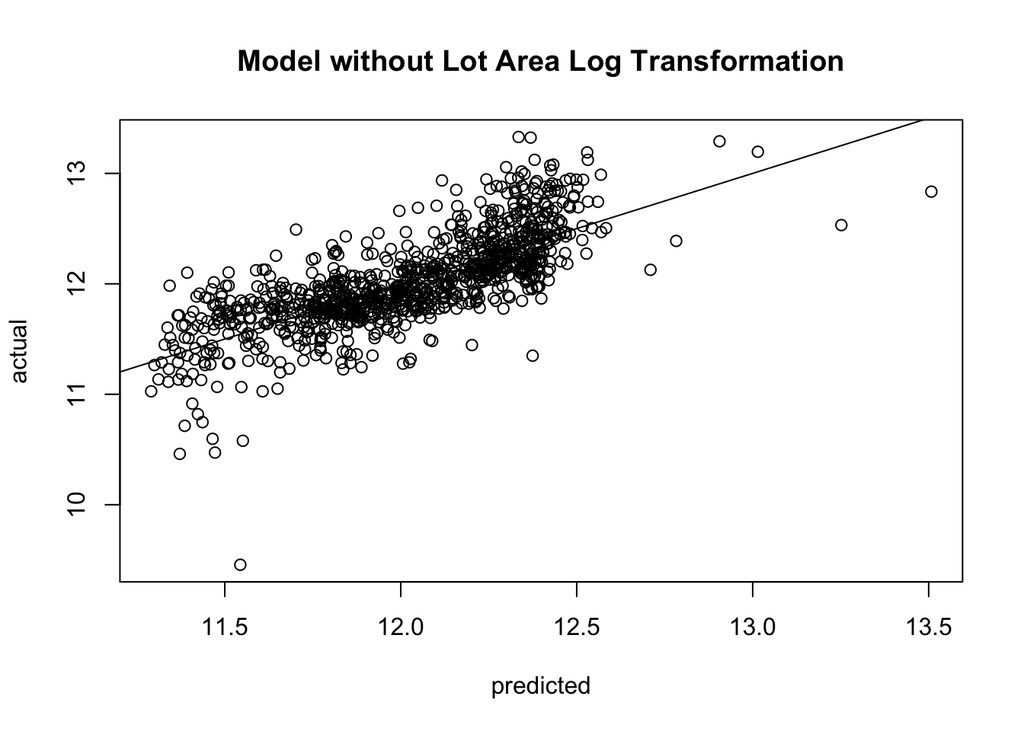

```r
# type your code for Question 7 here, and Knit
plot(predict(final_model), log(ames_train$price),
     main="Model without Lot Area Log Transformation",
     xlab="predicted",ylab="actual")
 abline(a=0,b=1)
```

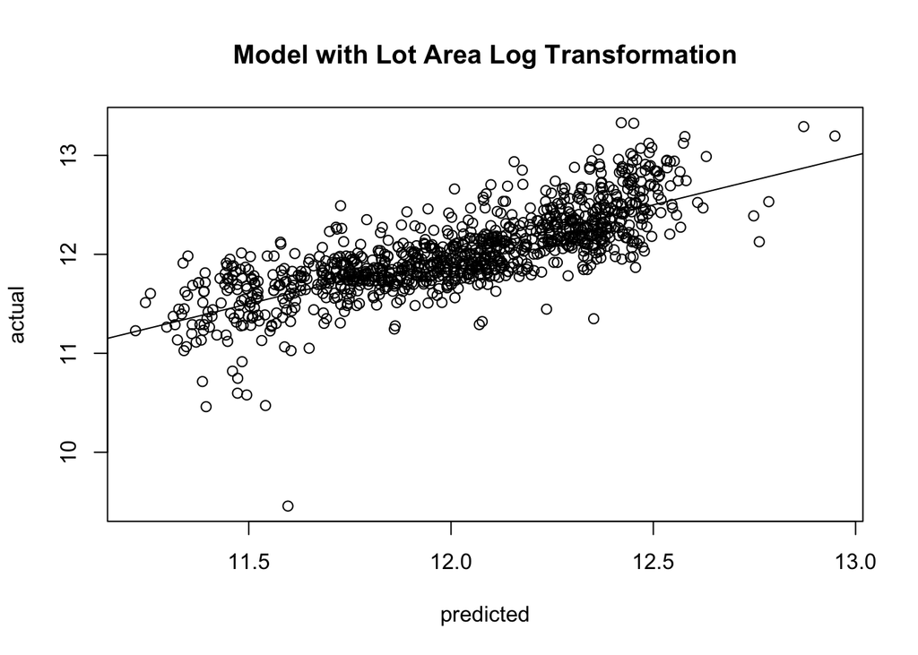

```r
plot(predict(lm_log_lotArea), log(ames_train$price),
     main="Model with Lot Area Log Transformation",
     xlab="predicted",ylab="actual")
 abline(a=0,b=1)
```

From the plots it’s clear that using a log transformation on Lot.Area tends to reduce the difference between real and predicted values as they are closer to the regression line, indicating smaller residuals. In fact, residuals are more evenly distributed which indicates lower standard errors and makes the model more reliable.

This is not the case **without** the Lot.Area log transformation where the residuals are `heteroskedastic`. This means that the variance of the error is not constant across the universe of house prices. This phenomena makes our model less reliable, despite the fact that the $R^2$ value is slightly lower.